# Import libraries

```python
# basics :
import pandas as pd
import numpy as np
from numpy import*
import datetime

# plot
import matplotlib.pyplot as plt
import seaborn as sns
%matplotlib inline

# impute and scale data
from sklearn.preprocessing import Imputer, StandardScaler, OneHotEncoder, FunctionTransformer
from sklearn.decomposition import PCA
# models
from sklearn.tree import DecisionTreeClassifier
from sklearn.linear_model import LogisticRegression
from sklearn.neighbors import KNeighborsClassifier
from sklearn.ensemble import GradientBoostingClassifier
# evaluation
from sklearn.model_selection import GridSearchCV, RandomizedSearchCV, train_test_split
from sklearn.pipeline import Pipeline, FeatureUnion
# metrics
from sklearn import metrics
from sklearn.metrics import classification_report, confusion_matrix, accuracy_score, roc_auc_score
# save models
from sklearn.externals import joblib
```

# Load data

```python
# read data
raw_data = pd.read_csv('caseintro/Assignment_Data.csv', sep=";")
variabletypes = pd.read_excel('caseintro/variabletypes.xlsx')
```

```python
# df for modelling and df_test for prediction submission
df = raw_data[raw_data.Target.isnull() == False]
df_test = raw_data[raw_data.Target.isnull() == True]
```

# Inspect data

```python
df.shape, df_test.shape
```

```
((2057, 55), (515, 55))
```

```python
variabletypes
```

|  | Test_Name | Type |
| --- | --- | --- |
| 0 | country_id | ID |
| 1 | application_id | ID |
| 2 | product_id | ID |
| 3 | v1 | Numeric |
| 4 | v2 | Numeric |
| 5 | v3 | Numeric |
| 6 | v4 | Numeric |
| 7 | v5 | Categorical |
| 8 | v6 | Categorical |
| 9 | v7 | Numeric |
| 10 | due_date | Date |
| 11 | first_status_day_date | Date |
| 12 | first_status_time_of_day | Date |
| 13 | paid_date | Date |
| 14 | v8 | Numeric |
| 15 | customer_id | ID |
| 16 | arrived_date | Date |
| 17 | v9 | Numeric |
| 18 | v10 | Numeric |
| 19 | v11 | Numeric |
| 20 | v12 | Categorical |
| 21 | v13 | Ordinal |
| 22 | v14 | Ordinal |
| 23 | v15 | Numeric |
| 24 | v16 | Numeric |
| 25 | v17 | Numeric |
| 26 | v18 | Numeric |
| 27 | v19 | Numeric |
| 28 | v20 | Numeric |
| 29 | v21 | Numeric |
| 30 | v22 | Numeric |
| 31 | v23 | Numeric |
| 32 | v24 | Numeric |
| 33 | v25 | Numeric |
| 34 | v26 | Numeric |
| 35 | v27 | Numeric |
| 36 | v28 | Numeric |
| 37 | v29 | Numeric |
| 38 | v30 | Numeric |
| 39 | v31 | Numeric |
| 40 | v32 | Numeric |
| 41 | v33 | Numeric |
| 42 | v34 | Numeric |
| 43 | v35 | Numeric |
| 44 | v36 | Numeric |
| 45 | v37 | Numeric |
| 46 | v38 | Numeric |
| 47 | v39 | Numeric |
| 48 | v40 | Numeric |
| 49 | v41 | Numeric |
| 50 | v42 | Date |
| 51 | v43 | Date |
| 52 | v44 | Date |
| 53 | v45 | Categorical |
| 54 | Target | Binary |

```python
variabletypes.groupby('Type').size()
```

```
Type
Binary          1
Categorical     4
Date            8
ID              4
Numeric        36
Ordinal         2
dtype: int64
```

Ordinal is like categoricals but with order.

# Clean data

```python
# rename for quicker typing
df.columns = df.columns.str.replace('Variable_', 'v')
variabletypes.columns = variabletypes.columns.str.replace('Variable_', 'v')
df.rename(columns = {'Target':'y'}, inplace = True)
```

```python
df.head().T
```

|  | 0 | 1 | 2 | 3 | 4 |
| --- | --- | --- | --- | --- | --- |
| country_id | 21 | 21 | 21 | 21 | 21 |
| application_id | 24176 | 24185 | 24215 | 24220 | 24255 |
| product_id | 21210001 | 21210001 | 21210001 | 21210001 | 21210001 |
| v1 | 35 | 30 | 30 | 30 | 30 |
| v2 | 1 | 1 | 1 | 1 | 2 |
| v3 | 1 | 1 | 1 | 1 | 1 |
| v4 | 1 | 1 | 1 | 1 | 1 |
| v5 | N | N | N | N | N |
| v6 | 72 | 25 | 65 | 65 | 4 |
| v7 | 27 | 26 | 21 | 48 | 28 |
| due_date | 07/07/2015 | 02/07/2015 | 02/07/2015 | 17/07/2015 | 02/07/2015 |
| first_status_day_date | 01/06/2015 | 01/06/2015 | 01/06/2015 | 01/06/2015 | 01/06/2015 |
| first_status_time_of_day | 00:43:22 | 07:56:36 | 11:02:04 | 11:22:37 | 15:27:18 |
| paid_date | 02/06/2015 | 02/06/2015 | 02/06/2015 | 17/06/2015 | 02/06/2015 |
| v8 | 100 | 199 | 100 | 199 | 199 |
| customer_id | 2970192 | 2970195 | 2970204 | 2970206 | 2430110 |
| arrived_date | 01/06/2015 00:43 | 01/06/2015 07:56 | 01/06/2015 11:02 | 01/06/2015 11:22 | 01/06/2015 15:27 |
| v9 | 190 | 199 | 100 | 199 | 600 |
| v10 | 100 | 199 | 100 | 199 | 199 |
| v11 | 100 | 199 | 100 | 199 | 199 |
| v12 | 15 | 15 | 15 | 15 | 15 |
| v13 | M | M | G | D | NaN |
| v14 | RATINGSTUFE M | RATINGSTUFE M | RATINGSTUFE G | RATINGSTUFE D | NaN |
| v15 | 0 | 4 | 1 | 0 | NaN |
| v16 | 0 | 1 | 2 | 0 | NaN |
| v17 | 0 | 0 | 0 | 0 | NaN |
| v18 | 0 | 0 | 0 | 0 | NaN |
| v19 | 1 | 0 | 0 | 0 | NaN |
| v20 | NaN | 25000 | 499 | NaN | NaN |
| v21 | NaN | NaN | NaN | NaN | NaN |
| v22 | NaN | 100 | 200 | NaN | NaN |
| v23 | 1 | 0 | 0 | 0 | NaN |
| v24 | 0 | 0 | 0 | 0 | NaN |
| v25 | 0 | 0 | 0 | 0 | NaN |
| v26 | 0 | 0 | 0 | 0 | NaN |
| v27 | 1 | 4 | 0 | 0 | NaN |
| v28 | 0 | 0 | 0 | 0 | NaN |
| v29 | 0 | 0 | 0 | 0 | NaN |
| v30 | 0 | 0 | 0 | 0 | NaN |
| v31 | 0 | 0 | 0 | 0 | NaN |
| v32 | 0 | 0 | 0 | 0 | NaN |
| v33 | 0 | 0 | 0 | 0 | NaN |
| v34 | 0 | 0 | 0 | 0 | NaN |
| v35 | 0 | 0 | 0 | 0 | NaN |
| v36 | 0 | 0 | 0 | 0 | NaN |
| v37 | NaN | 40147 | 499 | NaN | NaN |
| v38 | NaN | NaN | NaN | NaN | NaN |
| v39 | NaN | 100 | 300 | NaN | NaN |
| v40 | 0 | 0 | 0 | 0 | NaN |
| v41 | 0 | 0 | 0 | 0 | NaN |
| v42 | NaN | NaN | NaN | NaN | NaN |
| v43 | NaN | NaN | NaN | NaN | NaN |
| v44 | 14/06/2013 | NaN | NaN | NaN | NaN |
| v45 | F | M | F | F | F |
| y | 1 | 1 | 0 | 1 | 1 |

Based on the output above:

- Remove variables with only 1 unique value are removed, as they won't be predictive. (Later, in the feature selection, we might remove cols with low variance.)
- Recode v45 into Male
- v5 is a boolean qq recode
- arrived_date contains date & time, split it up? qq
- v14 must be recoded?

```python
# Remove zero variance varibles
cols_novariance = df.columns[df.apply(lambda x: x.nunique() == 1).values]
df.drop(cols_novariance, inplace = True, axis = 1)
```

```python
# Rename and recode Variable 45 to Male = True/False, elr så är det gjort med ett paket.
```

```python
# Variable_14 must recode something? qq
```

```python
df.v45.unique() # see that this must be recoded
df.loc[df.v45 == 'M', 'v45'] = 1
df.loc[df.v45 == 'F', 'v45'] = 0
df.loc[df.v45 == '?', 'v45'] = np.nan
```

```python
# cols with NA count > 40%
cols_manyna = df.isnull().mean().sort_values().tail(9).index
df.isnull().mean().sort_values().tail(9)
```

```
v20    0.415654
v37    0.415654
v22    0.688381
v39    0.688381
v21    0.770540
v38    0.770540
v44    0.916869
v43    0.942149
v42    0.954302
dtype: float64
```

There is a clear "elbow" at 9 values since the 10th value has only 7% NA whereas the 9th value has 42 NA. We might decide to drop cols with high NA count.

# Correct dtype

```python
# save cols with different dtypes (must intersect with df.columns because some are dropped)
cols_cat = list(set(variabletypes[variabletypes.Type == 'Categorical'].Test_Name) & set(df.columns))
cols_cato = list(set(variabletypes[variabletypes.Type == 'Ordinal'].Test_Name) & set(df.columns))
cols_num = list(set(variabletypes[variabletypes.Type == 'Numeric'].Test_Name) & set(df.columns))
cols_date = list(set(variabletypes[variabletypes.Type == 'Date'].Test_Name) & set(df.columns))
cols_id = list(set(variabletypes[variabletypes.Type == 'ID'].Test_Name) & set(df.columns))
```

# EDA

## Date columns

```python
# convert to correct time (see other project and sNotes for attempt at generalizing the approach . qqe2)
df[cols_date].head()
```

|  | first_status_day_date | first_status_time_of_day | due_date | v44 | arrived_date | v42 | v43 | paid_date |
| --- | --- | --- | --- | --- | --- | --- | --- | --- |
| 0 | 01/06/2015 | 00:43:22 | 07/07/2015 | 14/06/2013 | 01/06/2015 00:43 | NaN | NaN | 02/06/2015 |
| 1 | 01/06/2015 | 07:56:36 | 02/07/2015 | NaN | 01/06/2015 07:56 | NaN | NaN | 02/06/2015 |
| 2 | 01/06/2015 | 11:02:04 | 02/07/2015 | NaN | 01/06/2015 11:02 | NaN | NaN | 02/06/2015 |
| 3 | 01/06/2015 | 11:22:37 | 17/07/2015 | NaN | 01/06/2015 11:22 | NaN | NaN | 17/06/2015 |
| 4 | 01/06/2015 | 15:27:18 | 02/07/2015 | NaN | 01/06/2015 15:27 | NaN | NaN | 02/06/2015 |

```python
df[cols_date] = df[cols_date].apply(lambda x: pd.to_datetime(x))
```

## Categorical columns

```python
df[cols_cat].apply(lambda x: x.nunique())
```

```
v45     2
v12     6
v6     96
dtype: int64
```

qq v6 has 96 categories. creates a lot of dummies. maybe a bad col to use.

```python
df.v45.unique(), df.v12.unique()
```

```
(array([0, 1, nan], dtype=object),
 array([ 15. ,   0. ,  99. ,  45. ,  22.5,  31.5]))
```

v12 looks strange. Maybe it's strange on purpose so that we apply one hot encoding to categorical variables.

## Ordinal columns (ordered categorical)

```python
df[cols_cato].apply(lambda x: x.nunique())
```

```
v13    12
v14    12
dtype: int64
```

```python
df.v13.unique()
```

```
array(['M', 'G', 'D', nan, 'K', 'I', 'F', 'H', 'L', 'E', 'B', 'C', 'A'], dtype=object)
```

```python
df.v13.isnull().sum()
```

```
54
```

```python
df.v14.unique()
```

```
array(['RATINGSTUFE M', 'RATINGSTUFE G', 'RATINGSTUFE D', nan,
       'RATINGSTUFE K', 'RATINGSTUFE I', 'RATINGSTUFE F', 'RATINGSTUFE H',
       'RATINGSTUFE L', 'RATINGSTUFE E', 'RATINGSTUFE B', 'RATINGSTUFE C',
       'RATINGSTUFE A'], dtype=object)
```

```python
df.v14.isnull().sum()
```

```
54
```

```python
df.loc[1:5, ['v13', 'v14']]
```

|  | v13 | v14 |
| --- | --- | --- |
| 1 | M | RATINGSTUFE M |
| 2 | G | RATINGSTUFE G |
| 3 | D | RATINGSTUFE D |
| 4 | NaN | NaN |
| 5 | K | RATINGSTUFE K |

Coincidence? I think not.

```python
# qq write code that assert v13 and v14 are the same
# assert 0 == (df.v14.replace('RATINGSTUFE ', '') != df.v13).sum()
```

```python
df.drop('v14', inplace = True, axis = 1)
```

qq does sklearn care if I do onehot encoding or code it as 1,2,3,4,... ? I will anyway for now Do it like

```python
df.v13 = df.v13.map({'A':1, 'B':2, 'C':3, 'D':4, 'E':5, 'F':6, 'G':7, 'H':8, 'I':9, 'J':10, 'K':11, 'L':12})
```

qq ad v13 to _col ? and them remove _colo?

## Numerical columns

```python
df[cols_num].describe()
```

|  | v9 | v29 | v39 | v11 | v15 | v25 | v16 | v4 | v20 | v35 | ... | v1 | v7 | v24 | v36 | v18 | v17 | v10 | v23 | v22 | v38 |
| --- | --- | --- | --- | --- | --- | --- | --- | --- | --- | --- | --- | --- | --- | --- | --- | --- | --- | --- | --- | --- | --- |
| count | 2057.000000 | 1910.000000 | 641.000000 | 2057.000000 | 1910.000000 | 1910.000000 | 1910.000000 | 2057.000000 | 1202.000000 | 1910.000000 | ... | 2057.000000 | 2056.000000 | 1910.00000 | 1910.000000 | 1910.000000 | 1910.000000 | 2057.000000 | 1910.000000 | 641.000000 | 472.000000 |
| mean | 233.929509 | 0.068063 | 3656.792512 | 202.875061 | 2.193194 | 0.020942 | 1.206806 | 1.000972 | 14753.156406 | 0.087958 | ... | 33.634905 | 32.388132 | 0.03822 | 0.026178 | 0.583770 | 0.328796 | 202.875061 | 0.147644 | 2381.258970 | 5309.817797 |
| std | 116.485196 | 0.387840 | 8456.056617 | 80.494015 | 2.683371 | 0.157179 | 3.015875 | 0.031174 | 13510.374813 | 0.422782 | ... | 8.894507 | 11.473110 | 0.20752 | 0.159706 | 0.865525 | 0.665515 | 80.494015 | 0.564519 | 7002.014037 | 8953.279439 |
| min | 50.000000 | 0.000000 | 100.000000 | 50.000000 | 0.000000 | 0.000000 | 0.000000 | 1.000000 | 100.000000 | 0.000000 | ... | 7.000000 | 18.000000 | 0.00000 | 0.000000 | 0.000000 | 0.000000 | 50.000000 | 0.000000 | 100.000000 | 300.000000 |
| 25% | 199.000000 | 0.000000 | 300.000000 | 190.000000 | 0.000000 | 0.000000 | 0.000000 | 1.000000 | 4181.000000 | 0.000000 | ... | 30.000000 | 24.000000 | 0.00000 | 0.000000 | 0.000000 | 0.000000 | 190.000000 | 0.000000 | 200.000000 | 1250.000000 |
| 50% | 199.000000 | 0.000000 | 699.000000 | 199.000000 | 1.000000 | 0.000000 | 0.000000 | 1.000000 | 11000.000000 | 0.000000 | ... | 30.000000 | 29.000000 | 0.00000 | 0.000000 | 0.000000 | 0.000000 | 199.000000 | 0.000000 | 460.000000 | 3000.000000 |
| 75% | 300.000000 | 0.000000 | 2720.000000 | 200.000000 | 4.000000 | 0.000000 | 1.000000 | 1.000000 | 21948.500000 | 0.000000 | ... | 30.000000 | 38.000000 | 0.00000 | 0.000000 | 1.000000 | 0.000000 | 200.000000 | 0.000000 | 800.000000 | 5000.000000 |
| max | 600.000000 | 10.000000 | 76541.000000 | 500.000000 | 20.000000 | 3.000000 | 32.000000 | 2.000000 | 78398.000000 | 8.000000 | ... | 60.000000 | 86.000000 | 2.00000 | 1.000000 | 7.000000 | 5.000000 | 500.000000 | 11.000000 | 76000.000000 | 94670.000000 |

8 rows × 29 columns

```python
# qq write code to check if any of the cols above are identical, or simple tranformations of each other (will lead to collinearyt for example)
```

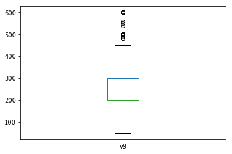

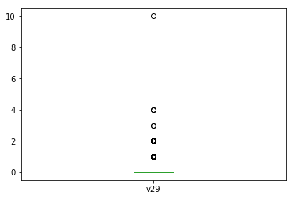

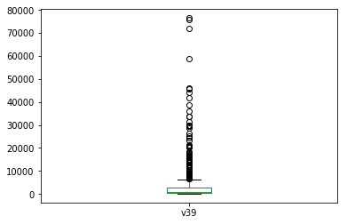

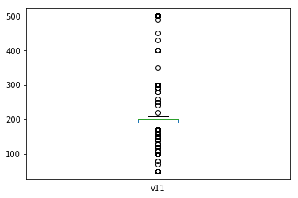

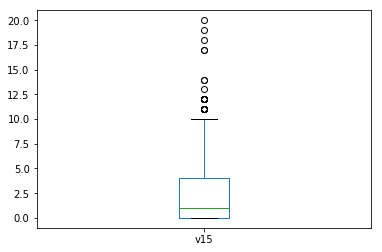

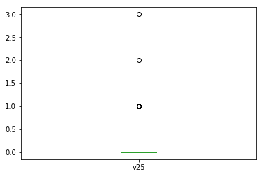

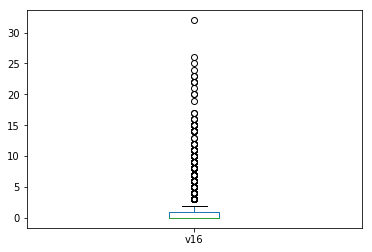

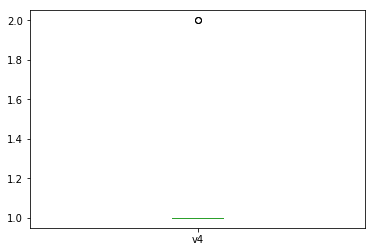

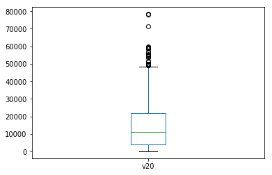

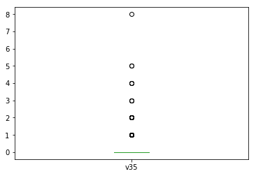

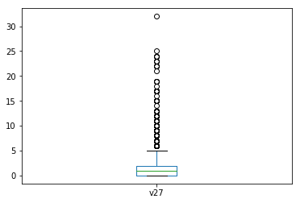

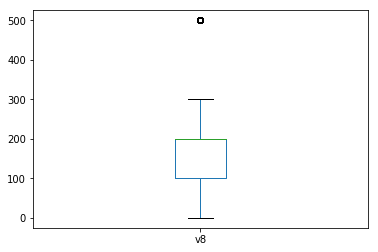

[17 more figures not shown]

```python
for col in cols_num:
    df[col].plot.box()
    plt.show()
```

# Quick pipeline test

Plan:

## 1)

```python
#X = df[['v1', 'v2', 'v4']]
X = df[cols_num]
y = df.y

X.shape, y.shape
```

```
((2057, 29), (2057,))
```

```python
X.describe()
```

|  | v9 | v29 | v39 | v11 | v15 | v25 | v16 | v4 | v20 | v35 | ... | v1 | v7 | v24 | v36 | v18 | v17 | v10 | v23 | v22 | v38 |
| --- | --- | --- | --- | --- | --- | --- | --- | --- | --- | --- | --- | --- | --- | --- | --- | --- | --- | --- | --- | --- | --- |
| count | 2057.000000 | 1910.000000 | 641.000000 | 2057.000000 | 1910.000000 | 1910.000000 | 1910.000000 | 2057.000000 | 1202.000000 | 1910.000000 | ... | 2057.000000 | 2056.000000 | 1910.00000 | 1910.000000 | 1910.000000 | 1910.000000 | 2057.000000 | 1910.000000 | 641.000000 | 472.000000 |
| mean | 233.929509 | 0.068063 | 3656.792512 | 202.875061 | 2.193194 | 0.020942 | 1.206806 | 1.000972 | 14753.156406 | 0.087958 | ... | 33.634905 | 32.388132 | 0.03822 | 0.026178 | 0.583770 | 0.328796 | 202.875061 | 0.147644 | 2381.258970 | 5309.817797 |
| std | 116.485196 | 0.387840 | 8456.056617 | 80.494015 | 2.683371 | 0.157179 | 3.015875 | 0.031174 | 13510.374813 | 0.422782 | ... | 8.894507 | 11.473110 | 0.20752 | 0.159706 | 0.865525 | 0.665515 | 80.494015 | 0.564519 | 7002.014037 | 8953.279439 |
| min | 50.000000 | 0.000000 | 100.000000 | 50.000000 | 0.000000 | 0.000000 | 0.000000 | 1.000000 | 100.000000 | 0.000000 | ... | 7.000000 | 18.000000 | 0.00000 | 0.000000 | 0.000000 | 0.000000 | 50.000000 | 0.000000 | 100.000000 | 300.000000 |
| 25% | 199.000000 | 0.000000 | 300.000000 | 190.000000 | 0.000000 | 0.000000 | 0.000000 | 1.000000 | 4181.000000 | 0.000000 | ... | 30.000000 | 24.000000 | 0.00000 | 0.000000 | 0.000000 | 0.000000 | 190.000000 | 0.000000 | 200.000000 | 1250.000000 |
| 50% | 199.000000 | 0.000000 | 699.000000 | 199.000000 | 1.000000 | 0.000000 | 0.000000 | 1.000000 | 11000.000000 | 0.000000 | ... | 30.000000 | 29.000000 | 0.00000 | 0.000000 | 0.000000 | 0.000000 | 199.000000 | 0.000000 | 460.000000 | 3000.000000 |
| 75% | 300.000000 | 0.000000 | 2720.000000 | 200.000000 | 4.000000 | 0.000000 | 1.000000 | 1.000000 | 21948.500000 | 0.000000 | ... | 30.000000 | 38.000000 | 0.00000 | 0.000000 | 1.000000 | 0.000000 | 200.000000 | 0.000000 | 800.000000 | 5000.000000 |
| max | 600.000000 | 10.000000 | 76541.000000 | 500.000000 | 20.000000 | 3.000000 | 32.000000 | 2.000000 | 78398.000000 | 8.000000 | ... | 60.000000 | 86.000000 | 2.00000 | 1.000000 | 7.000000 | 5.000000 | 500.000000 | 11.000000 | 76000.000000 | 94670.000000 |

8 rows × 29 columns

```python
X_train, X_test, y_train, y_test = train_test_split(X, y, test_size = 0.30, random_state=9)
```

```python
steps = [
    # preprocess:
    ('imp', Imputer(strategy='mean')),
    ('scale', StandardScaler()), # zero mean and unit variance
    ('pca', PCA(2)),

    # classifier:
    # ('clf', LogisticRegression())
    ('clf', GradientBoostingClassifier())
]
pipe = Pipeline(steps=steps)
pipe
```

```
Pipeline(memory=None,
     steps=[('imp', Imputer(axis=0, copy=True, missing_values='NaN', strategy='mean', verbose=0)), ('scale', StandardScaler(copy=True, with_mean=True, with_std=True)), ('pca', PCA(copy=True, iterated_power='auto', n_components=2, random_state=None,
  svd_solver='auto', tol=0.0, whiten=False)), ('clf', Gr...      presort='auto', random_state=None, subsample=1.0, verbose=0,
              warm_start=False))])
```

```python
pipe.fit(X_train, y_train)
y_pred_proba = pipe.predict_proba(X_test)[:, 1]
roc_auc_score(y_test, y_pred_proba)
```

```
0.58389432560033605
```

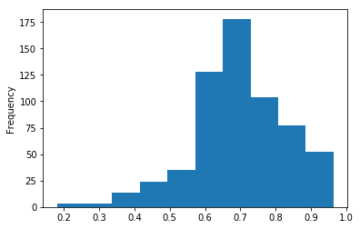

```python
pd.Series(y_pred_proba).plot.hist()
```

## 2)

```python
cols_cat
```

```
['v45', 'v12', 'v6']
```

```python
df[cols_cat].isnull().sum()
```

```
v45     7
v12     0
v6     35
dtype: int64
```

```python
X = df[cols_cat]
```

```python
X.head()
```

|  | v45 | v12 | v6 |
| --- | --- | --- | --- |
| 0 | 0 | 15.0 | 72.0 |
| 1 | 1 | 15.0 | 25.0 |
| 2 | 0 | 15.0 | 65.0 |
| 3 | 0 | 15.0 | 65.0 |
| 4 | 0 | 15.0 | 4.0 |

```python
X_train, X_test, y_train, y_test = train_test_split(X, y, test_size = 0.30, random_state=9)
```

```python
# can be used as a boolean for OneHotEncoder
cols_cat_bool = X.columns.isin(cols_cat)
```

```python
steps2 = [
    # preprocess:
    ('imp', Imputer(strategy='most_frequent')),
    ('onehot', OneHotEncoder(categorical_features = cols_cat_bool)),
    #('scale', StandardScaler()), # zero mean and unit variance
    #('pca', PCA(2)),

    # classifier:
    # ('clf', LogisticRegression())
     ('clf', GradientBoostingClassifier())
]
pipe = Pipeline(steps = steps2)
pipe
```

```
Pipeline(memory=None,
     steps=[('imp', Imputer(axis=0, copy=True, missing_values='NaN', strategy='most_frequent',
    verbose=0)), ('onehot', OneHotEncoder(categorical_features=array([ True,  True,  True], dtype=bool),
       dtype=<class 'numpy.float64'>, handle_unknown='error',
       n_values='auto', sparse=True)), ('cl...      presort='auto', random_state=None, subsample=1.0, verbose=0,
              warm_start=False))])
```

```python
pipe.fit(X_train, y_train)
y_pred_proba = pipe.predict_proba(X_test)[:, 1]
roc_auc_score(y_test, y_pred_proba)
```

```
0.537235464043471
```

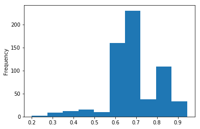

```python
pd.Series(y_pred_proba).plot.hist()
```

## 3)

```python
cols_cat
```

```
['v45', 'v12', 'v6']
```

```python
cols_1 = ['v1', 'v2', 'v4',    'v45', 'v12', 'v6']
```

```python
variabletypes.loc[variabletypes.Test_Name.isin(cols_1)]
```

|  | Test_Name | Type |
| --- | --- | --- |
| 3 | v1 | Numeric |
| 4 | v2 | Numeric |
| 6 | v4 | Numeric |
| 8 | v6 | Categorical |
| 20 | v12 | Categorical |
| 53 | v45 | Categorical |

```python
X = df[cols_1]
y = df.y

X.shape, y.shape
```

```
((2057, 6), (2057,))
```

```python
X.describe()
```

|  | v1 | v2 | v4 | v12 | v6 |
| --- | --- | --- | --- | --- | --- |
| count | 2057.000000 | 2057.00000 | 2057.000000 | 2057.000000 | 2022.000000 |
| mean | 33.634905 | 1.31016 | 1.000972 | 36.929023 | 48.885757 |
| std | 8.894507 | 0.72481 | 0.031174 | 28.130961 | 26.271963 |
| min | 7.000000 | 1.00000 | 1.000000 | 0.000000 | 1.000000 |
| 25% | 30.000000 | 1.00000 | 1.000000 | 15.000000 | 26.000000 |
| 50% | 30.000000 | 1.00000 | 1.000000 | 45.000000 | 49.000000 |
| 75% | 30.000000 | 1.00000 | 1.000000 | 45.000000 | 70.000000 |
| max | 60.000000 | 10.00000 | 2.000000 | 99.000000 | 99.000000 |

```python
X.isnull().sum()
```

```
v1      0
v2      0
v4      0
v45     7
v12     0
v6     35
dtype: int64
```

qq is 0 and 1 equally good as 1 and 2? if not, remove 1 from v4 as it ranges from 1 to 2.

```python
X_train, X_test, y_train, y_test = train_test_split(X, y, test_size = 0.30, random_state=9)
```

```python
cols_catnum = cols_cat + cols_num
```

```python
get_categorical_cols = FunctionTransformer(lambda x: x[cols_cat], validate=False)
# what about cato i.e. ordinal data?
get_numerical_cols = FunctionTransformer(lambda x: x[cols_num], validate=False)

numerical_pipeline = Pipeline([
    ('selector', get_categorical_cols),
    ('imputer', Imputer())
])

categorical_pipeline = Pipeline([
    ('selector', get_numerical_cols),
    ('imputer', Imputer(strategy = 'most_frequent')),
    ('onehot', OneHotEncoder())
])

union = FeatureUnion([
    ('numeric', numerical_pipeline),
    ('categorical', categorical_pipeline)
])

pl = Pipeline([
    ('union', union),
    ('clf', (LogisticRegression()))
])
```

```python
pl
```

```
Pipeline(memory=None,
     steps=[('union', FeatureUnion(n_jobs=1,
       transformer_list=[('numeric', Pipeline(memory=None,
     steps=[('selector', FunctionTransformer(accept_sparse=False,
          func=<function <lambda> at 0x7f17fc174730>, inv_kw_args=None,
          inverse_func=None, kw_args=None, pass_y='deprecated',...ty='l2', random_state=None, solver='liblinear', tol=0.0001,
          verbose=0, warm_start=False))])
```

```python
pl.fit(X_train, y_train)
```

[output not shown]

[output cut: 117 more lines]

[output not shown]